# Eindopdracht

Laurine Seelt

2022-04-12

*Introductie* In dit onderzoek zijn er fibroblasten, oftewel huidcellen, uit één proefpersoon gehaald. Een deel van deze fibroblasten is behandeld met een controle transcriptiefactor, BCLXL. Het andere deel is behandeld met de transcriptiefactor ONECUT3, waarvan men vermoedt dat het ervoor zorgt dat fibroblasten worden omgezet in hersencellen. Na behandeling met een van deze transcriptiefactoren is er naar de genexpressie van de cellen gekeken. Om dit te bekijken, zijn van beide groepen RNA-sequencing datasets gegenereerd.

*Count table*

```r
##Input directory maken voor de bam files
bam_directory <- "/home/daur2/rnaseq/rnaseq_onecut/bam/"
##Output directory maken voor de count tables
counts_directory <- "/home/daur2/rnaseq/rnaseq_onecut/counts/"
##Vector met de namen van de bam files maken
bam_names <- list.files(bam_directory, pattern = ".*[9056]\\.bam$", full.names = TRUE)
##Reads per gen tellen met de NCBI ref-seq annotations
read_counts_OC3 <- featureCounts(
  files = bam_names,
  annot.inbuilt = "hg38",
  useMetaFeatures = TRUE, ##fragmenten per gen tellen en niet per transcript
  strandSpecific = 1, ##stranded protocol
  isPairedEnd = TRUE,
  countReadPairs = TRUE, ##fragmenten tellen ipv reads
  nthreads = 10)
```

*DESeq object*

```r
##Eerst een count matrix maken
read_counts_OC3 <- readRDS("/home/daur2/rnaseq/rnaseq_onecut/counts/read_counts_OC3.rds")
count_matrix_OC3 <- read_counts_OC3$counts
##Sample data inlezen
metadata_OC3 <- read_csv("/home/daur2/rnaseq/rnaseq_onecut/onecut_sampledata_OC3.csv")
##Metadata omzetten naar een dataframe
metadata_OC3 <- as.data.frame(metadata_OC3)
##Rij namen veranderen
rownames(metadata_OC3) <- paste0(metadata_OC3$Run, ".bam")
##Controleren of de kolomnamen hetzelfde zijn in de count matrix als de rijnamen bij de metadata
colnames(count_matrix_OC3) == rownames(metadata_OC3)
```

```
## [1] TRUE TRUE TRUE TRUE
```

```r
##Kolom omzetten naar factor omdat dat nodig is om een DESeq object te maken
metadata_OC3$Cell_type <- metadata_OC3$Cell_type %>% factor(levels = c("Skin derived fibroblast overexpressing Bclxl", "2 days after induction of OC3 in skin derived fibroblasts"))
##DESeqDataSet object maken
dds_OC3 <- DESeqDataSetFromMatrix(
  countData = count_matrix_OC3,
  colData = metadata_OC3,
  design = ~ Cell_type)
```

*Staafdiagram met de percentages variatie per Principal Component*

```r
##Eerst de read counts normaliseren om de verschillen kleiner te maken
dds_OC3_normalized <- rlog(dds_OC3)
##PCA
pca_OC3 <- dds_OC3_normalized %>% assay() %>% t() %>% prcomp()
##Bekijken welk deel van de variatie door elke PC wordt verklaard
pca_OC3_summary <- summary(pca_OC3)$importance
pca_OC3_summary
```

```
##                             PC1      PC2      PC3         PC4
## Standard deviation     37.25778 7.955918 6.823376 2.63093e-13
## Proportion of Variance  0.92667 0.042250 0.031080 0.00000e+00
## Cumulative Proportion   0.92667 0.968920 1.000000 1.00000e+00
```

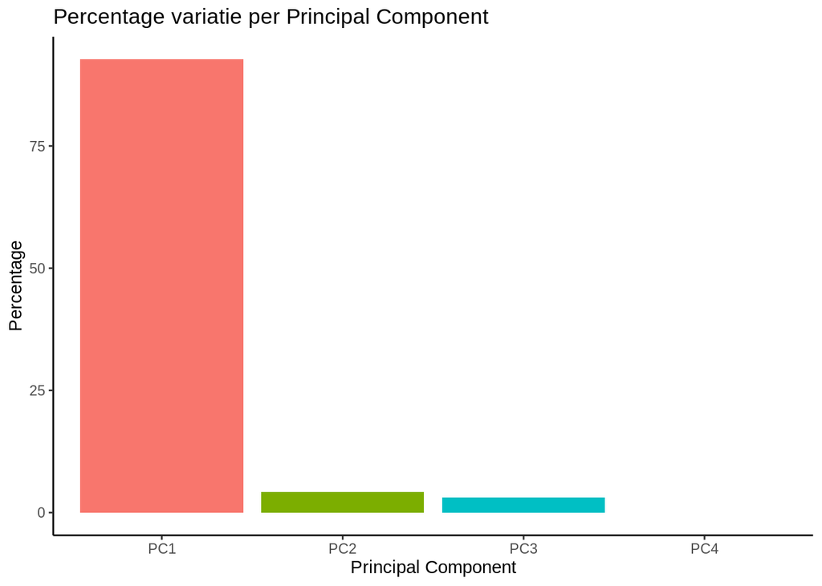

```r
##Dataframe maken met de metadata en de PCA waarden
pca_OC3_plotting <- cbind(metadata_OC3, pca_OC3$x)
##Percentages variatie per PC verkrijgen
PC1_OC3_var <- round(pca_OC3_summary["Proportion of Variance", "PC1"]*100, digits = 1)
PC2_OC3_var <- round(pca_OC3_summary["Proportion of Variance", "PC2"]*100, digits = 1)
PC3_OC3_var <- round(pca_OC3_summary["Proportion of Variance", "PC3"]*100, digits = 1)
PC4_OC3_var <- round(pca_OC3_summary["Proportion of Variance", "PC4"]*100, digits = 1)
##Tibble maken met de percentages
percentages <- tibble(pc = c("PC1", "PC2", "PC3", "PC4"), percentage = c(PC1_OC3_var, PC2_OC3_var, PC3_OC3_var, PC4_OC3_var))
##Staafdiagram maken met de percentages
percentages %>% ggplot(aes(x=pc, y = percentage, fill = pc))+
  geom_col()+
  theme_classic()+
  theme(legend.position = "none")+
  labs(title = "Percentage variatie per Principal Component",
       x = "Principal Component",
       y = "Percentage")
```

*PC1 vs. PC2*

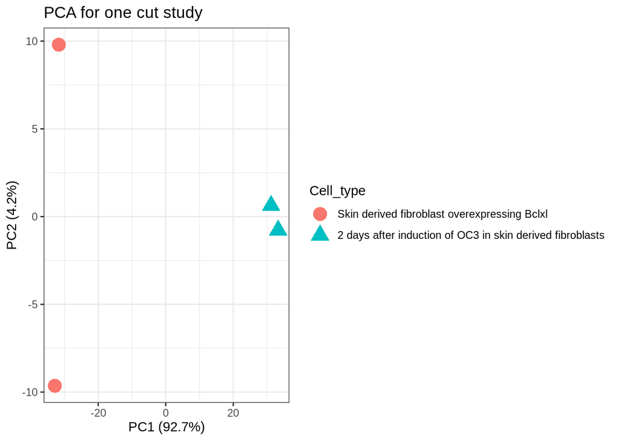

```r
ggplot(pca_OC3_plotting) +
  geom_point(aes(x=PC1, y=PC2, shape = Cell_type, color = Cell_type), size = 5) +
  ggtitle("PCA for one cut study") +
  xlab(paste0("PC1 (", PC1_OC3_var, "%)")) +
  ylab(paste0("PC2 (", PC2_OC3_var, "%)")) +
  theme_bw()
```

Bijna alle variatie kan worden samengevat in PC1, ruim 92%. Ook is te zien in de PCA dat de 2 behandelde samples qua variatie erg dicht bij elkaar liggen, terwijl de 2 onbehandelde samples ver(der) uit elkaar liggen. Ook is er in de PCA te zien dat er horizontaal erg veel afstand is tussen de 2 behandelde en onbehandelde samples. PC1 zit op de horizontale as, dus dit geeft aan dat er een (erg) groot verschil is tussen de samples als je iig kijkt naar PC1.

*DGE analyse*

```r
OC3_dge <- DESeq(dds_OC3)
OC3_dge_results <- results(OC3_dge, alpha = 0.05, lfcThreshold = 1) ##alleen genen die 2 of meer keer upgereguleerd of downgereguleerd zijn
summary(OC3_dge_results)
```

```
##
## out of 21139 with nonzero total read count
## adjusted p-value < 0.05
## LFC > 1.00 (up)    : 841, 4%
## LFC < -1.00 (down) : 758, 3.6%
## outliers [1]       : 0, 0%
## low counts [2]     : 5232, 25%
## (mean count < 3)
## [1] see 'cooksCutoff' argument of ?results
## [2] see 'independentFiltering' argument of ?results
```

*Volcano plot*

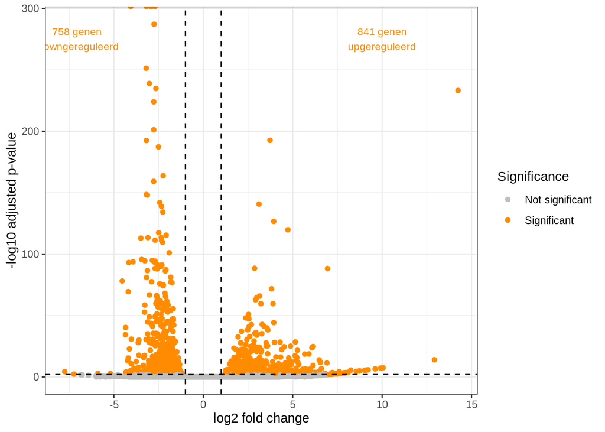

```r
##NA-waarden eruit halen
OC3_dge_plotting <- data.frame(OC3_dge_results) %>% filter(!is.na(padj))
##Kolom maken die aangeeft of het gen differentiëel tot expressie komt
OC3_dge_plotting <- OC3_dge_plotting %>% mutate(signif = if_else((padj < 0.01 & log2FoldChange > 1|padj < 0.01 & log2FoldChange<as.numeric(-1)), "Significant", "Not significant"))
##Volcano plot maken
OC3_dge_plotting %>%  ggplot(aes(x = log2FoldChange, y = -log10(padj), color = signif)) +
  geom_point() +
  xlab("log2 fold change") +
  ylab("-log10 adjusted p-value") +
  theme_bw() +
  scale_colour_manual(values = c("grey", "darkorange"), name = "Significance") +
   geom_hline(yintercept = -log10(0.01), linetype = "dashed") +
  geom_vline(xintercept = 1, linetype = "dashed") +
  geom_vline(xintercept = -1, linetype = "dashed") +
  annotate("text", x=10, y=275, label="841 genen\nupgereguleerd", color="darkorange", size=3)+
  annotate("text", x=-7, y=275, label="758 genen \ndowngereguleerd", color="darkorange", size=3)
```

*Heatmap*

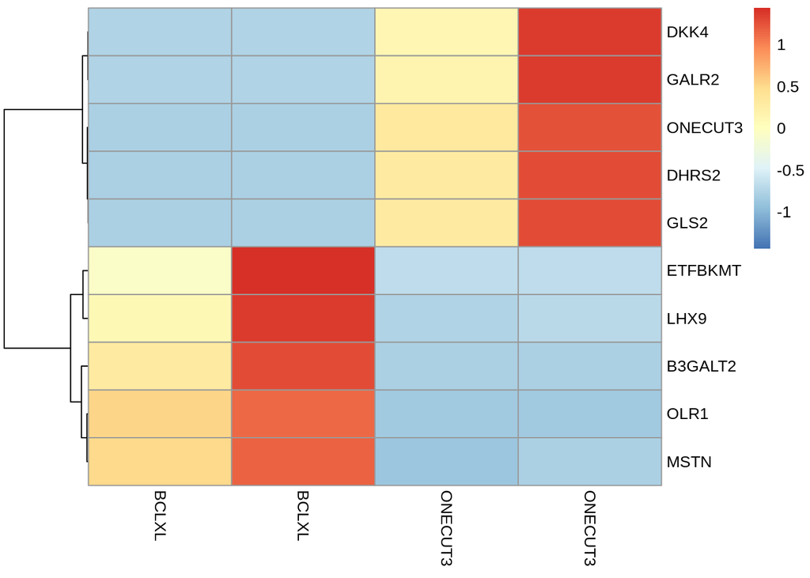

```r
##Resultaten filteren op p-waarde van 0.01
OC3_dge_results_0.01 <- OC3_dge_results %>% data.frame() %>% filter(padj<0.01)
##5 meest upgereguleerde en downgereguleerde genen verkrijgen
up_down_regulated_5 <- c(rownames(OC3_dge_results_0.01[order(OC3_dge_results_0.01$log2FoldChange, decreasing = TRUE)[1:5],]),rownames(OC3_dge_results_0.01[order(OC3_dge_results_0.01$log2FoldChange)[1:5],]))
count_values_OC3 <- assay(dds_OC3)[up_down_regulated_5,]
##Kolomnamen veranderen
colnames(count_values_OC3) <- c("BCLXL", "BCLXL", "ONECUT3", "ONECUT3")
#Rijnamen veranderen naar de symbolen
rownames(count_values_OC3) <- mapIds(org.Hs.eg.db,
                                     keys = up_down_regulated_5,
                                     keytype = "ENTREZID",
                                     column = "SYMBOL",
                                     multiVals = "first")
pheatmap(count_values_OC3, scale = "row", show_rownames = TRUE, cluster_cols = FALSE)
```

*Functie*

```r
GOidToSymbol <- function(GOid){
  IDs <- as.vector(mapIds(org.Hs.eg.db, keys = GOid, keytype = "GO", column = "SYMBOL", multiVals = "CharacterList"))
  return(IDs)
}
```

*GO term enrichment analyse upgereguleerde genen*

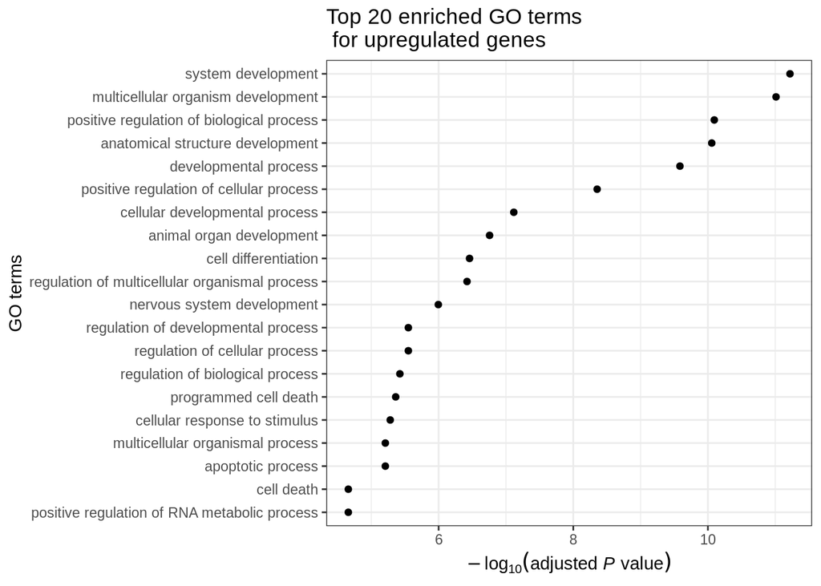

```r
##Lijst maken met upgereguleerde genen
upregulated_genes_OC3 <- OC3_dge_results %>% data.frame() %>%
  filter(log2FoldChange > 1, padj < 0.01) %>% rownames()
##Lijst van alle genen in de dataset maken
all_genes_OC3 <- OC3_dge_results %>% data.frame() %>% rownames()
##GO term enrichment analysis uitvoeren
test_object_high <- new("GOHyperGParams",
                   geneIds = upregulated_genes_OC3,
                   universeGeneIds = all_genes_OC3,
                   annotation = "org.Hs.eg.db",
                   ontology = "BP",
                   pvalueCutoff = 1,
                   testDirection = "over")
goterm_analysis_high <- hyperGTest(test_object_high)
##Dataframe met de resultaten maken
goterm_analysis_high_results <- summary(goterm_analysis_high)
##P-waarde aanpassen voor meerdere testen
goterm_analysis_high_results$padj <- p.adjust(goterm_analysis_high_results$Pvalue, method = "BH")
##Genen selecteren die langer zijn dan 5 en korter dan 500
goterm_analysis_high_results <- goterm_analysis_high_results %>% filter(Count > 5) %>% filter(Count < 500)
##Top 20 genen verkrijgen
goterm_analysis_high_top20 <- goterm_analysis_high_results[order(goterm_analysis_high_results$padj)[1:20],]
##Plotje maken
goterm_analysis_high_top20$Term <- factor(goterm_analysis_high_top20$Term,
                                     levels = goterm_analysis_high_top20$Term[
                                       order(goterm_analysis_high_top20$padj, decreasing = TRUE)])
goterm_analysis_high_top20 %>% ggplot(aes(x = Term, y = -log10(padj))) +
  geom_point() +
  coord_flip() +
  ylab(expression(-log[10](adjusted~italic(P)~value))) +
  xlab("GO terms") +
  ggtitle("Top 20 enriched GO terms\n for upregulated genes") +
  theme_bw()
```

*GO term enrichment analyse voor downgereguleerde genen*

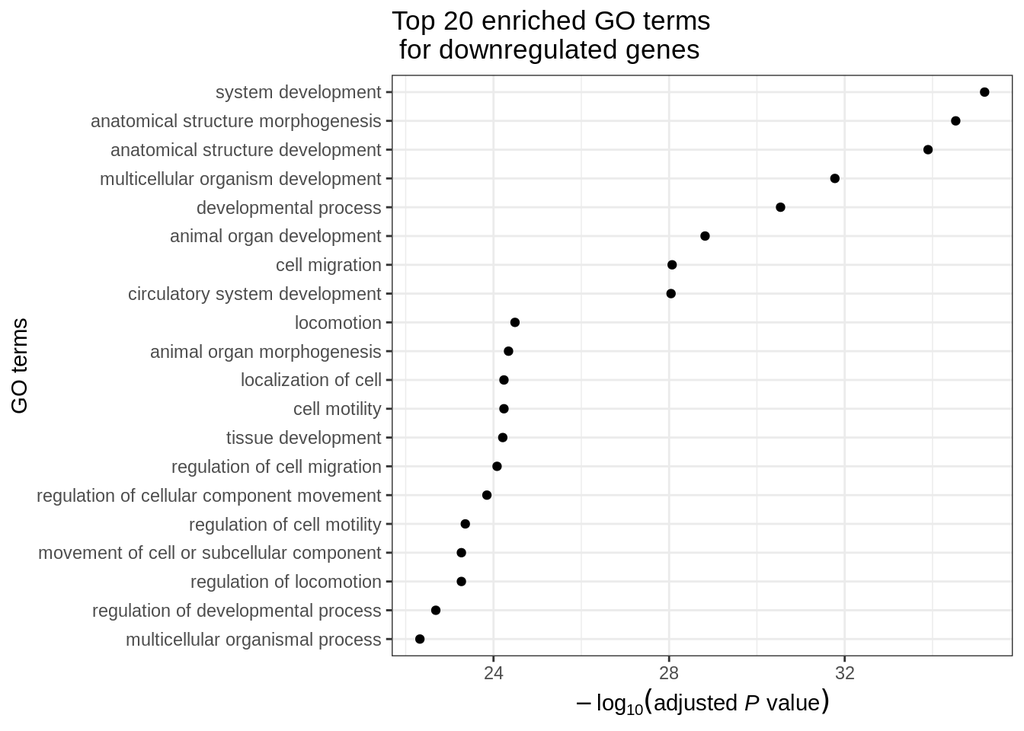

```r
##Lijst maken met downgereguleerde genen
downregulated_genes_OC3 <- OC3_dge_results %>% data.frame() %>% filter(log2FoldChange < -1, padj < 0.01) %>% row.names()
##Lijst van alle genen in de dataset maken
all_genes_OC3 <- OC3_dge_results %>% data.frame() %>% rownames()
##GO term enrichment analyse uitvoeren
test_object_low <- new("GOHyperGParams",
                   geneIds = downregulated_genes_OC3,
                   universeGeneIds = all_genes_OC3,
                   annotation = "org.Hs.eg.db",
                   ontology = "BP",
                   pvalueCutoff = 1,
                   testDirection = "over")
goterm_analysis_low <- hyperGTest(test_object_low)
##Dataframe met de resultaten verkrijgen
goterm_analysis_low_results <- summary(goterm_analysis_low)
##P-waarde aanpassen voor meerdere testen
goterm_analysis_low_results$padj <- p.adjust(goterm_analysis_low_results$Pvalue, method = "BH")
##Genen selecteren die langer zijn dan 5 en korter dan 500
goterm_analysis_low_results <- goterm_analysis_low_results %>% filter(Count > 5) %>% filter(Count < 500)
##Top 20 GO terms selecteren
goterm_analysis_low_top20 <- goterm_analysis_low_results[order(goterm_analysis_low_results$padj)[1:20],]
##Plotje :)
goterm_analysis_low_top20$Term <- factor(goterm_analysis_low_top20$Term,
                                     levels = goterm_analysis_low_top20$Term[
                                       order(goterm_analysis_low_top20$padj, decreasing = TRUE)])
goterm_analysis_low_top20 %>% ggplot(aes(x = Term, y = -log10(padj))) +
  geom_point() +
  coord_flip() +
  ylab(expression(-log[10](adjusted~italic(P)~value))) +
  xlab("GO terms") +
  ggtitle("Top 20 enriched GO terms\n for downregulated genes") +
  theme_bw()
```